# Capsule 2 - Estimer et interpréter

MQT-2101 - Analyse et modélisation des données

## Pourquoi ça compte

Que dit une probabilité?

Deux profils peuvent avoir des risques différents. Le modèle décrit une association, pas l’effet d’un contact.

## Objectifs de la capsule

- Ajuster une régression logistique sur l’apprentissage.
- Distinguer probabilité et cote.
- Interpréter un rapport de cotes sans conclusion causale.

## Passer du modèle à une probabilité

- La régression logistique traduit un prédicteur linéaire en probabilité.
- Pour une probabilité $p$, la cote vaut $p/(1-p)$.
- À autres variables fixées, $\exp(\beta)$ multiplie les cotes pour une unité supplémentaire du prédicteur.
- Une probabilité n’est ni une certitude ni un effet causal.

## Du risque à la cote, puis retour

Sur 100 clients comparables, un risque de 20 % correspond à 20 départs attendus.

| Quantité | Calcul | Valeur |
| --- | --- | --- |
| Cote initiale | 20 / 80 | 0,25 |
| Cote doublée | 2 × 0,25 | 0,50 |
| Nouvelle probabilité | 0,50 / (1 + 0,50) | 33,3 % |

Doubler la cote fait passer le risque de 20 % à 33,3 % dans cet exemple.

## Une courbe entre 0 et 1

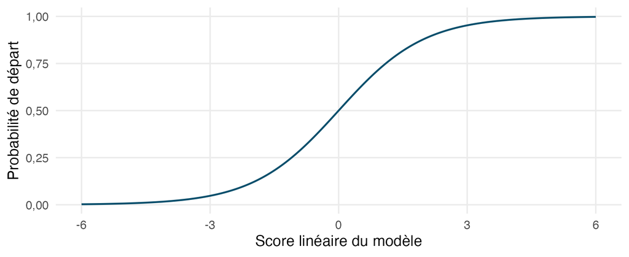

## Lire la sortie de la régression

Le modèle a été ajusté sur les 389 clients d’apprentissage.

| Changement, toutes choses égales | Multiplicateur des cotes de départ |
| --- | --- |
| Un ticket de service supplémentaire | 1,443 |
| Un point de satisfaction supplémentaire | 0,541 |
| Contrat mensuel comparé au contrat annuel | 1,920 |

Pour le contrat, nommez la catégorie de référence. Pour un ticket, nommez l’unité du changement.

## Deux fiches pour un seul contraste

Même contrat mensuel, 24 mois d’ancienneté, utilisation 12, satisfaction 7 et aucun rabais.

| Profil | Tickets sur six mois | Risque estimé |
| --- | --- | --- |
| A | 1 | 32,0 % |
| B | 3 | 49,5 % |

Le risque augmente d’environ 17,5 points de pourcentage entre les deux profils.

## Pourquoi deux tickets changent-ils la cote ?

Un ticket supplémentaire multiplie la cote par 1,443. Deux tickets multiplient la cote deux fois.

| Calcul avec les valeurs arrondies | Résultat |
| --- | --- |
| Cote du profil A : 0,320 / 0,680 | 0,471 |
| Cote du profil B : 0,471 × 1,443² | 0,981 |
| Probabilité : 0,981 / 1,981 | Environ 49,5 % |

Une même variation des cotes peut donner des écarts de probabilité différents selon le point de départ.

## Que peut conclure le service à la clientèle ?

Une gestionnaire propose de fermer deux tickets pour diminuer le risque d’un client.

| Ce que les deux profils établissent | Ce qu’il faudrait pour évaluer l’action |
| --- | --- |
| Le modèle associe davantage de tickets à un risque plus élevé. | Observer comment évoluent des groupes comparables avec et sans intervention. |

Un problème non résolu peut expliquer à la fois les tickets et le départ. Le contraste de profils ne mesure pas le bénéfice d’un appel.

## À retenir

Probabilité

risque compris entre 0 et 1, sans certitude individuelle

Cotes

un rapport de cotes n’est pas un rapport de probabilités

Référence

catégorie de comparaison et autres variables fixées

## Production autonome 10.2

Ajustez une régression logistique sur l’apprentissage. Interprétez un rapport de cotes et deux probabilités prédites sans les présenter comme une certitude ou un effet causal.

Cette production se réalise une seule fois dans le rapport guidé.

### Auto-vérification

- Je distingue une cote d’une probabilité.
- Je nomme la référence et les variables maintenues fixes.
- Je ne prétends pas mesurer l’effet de l’intervention.

## Références et crédits

Matériel MQT-2101, Université Laval. Données fictives simulées pour l’enseignement.

James, Witten, Hastie et Tibshirani (2021), *An Introduction to Statistical Learning*, 2e édition.